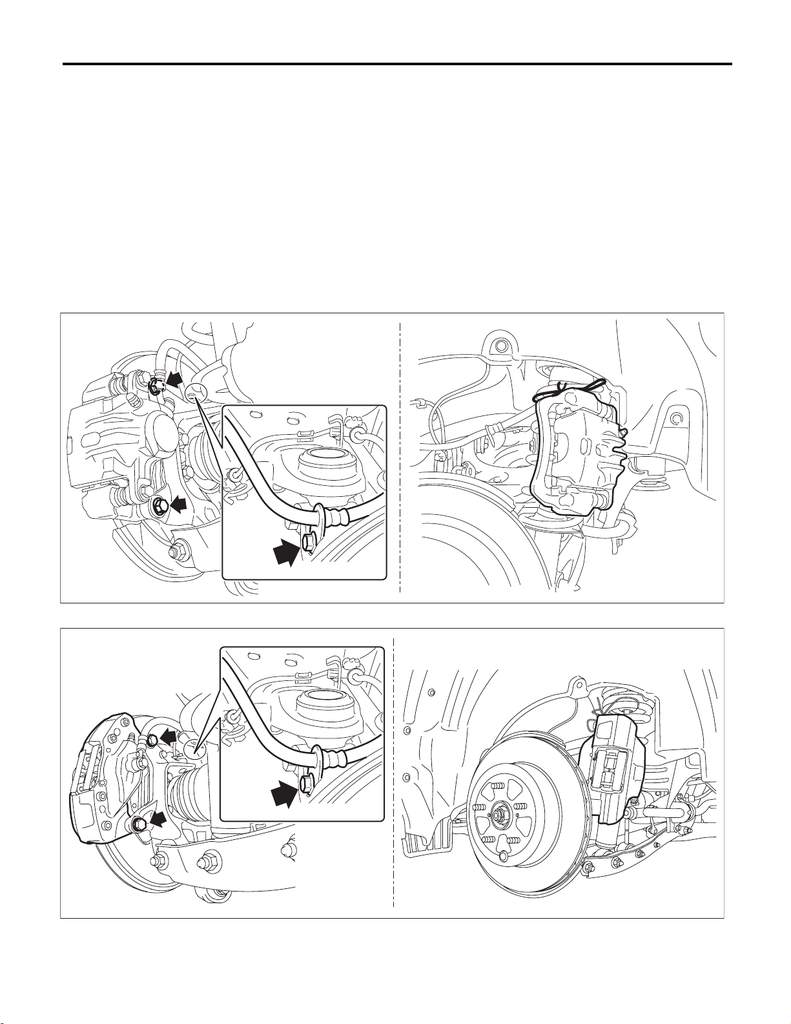

BR-39

Rear Disc Rotor

BRAKE

6. Rear Disc Rotor

A: REMOVAL

1) Lift up the vehicle, and then remove the rear wheels.

2) Release the lever assembly - hand brake.

3) Remove the disc brake assembly.

(1) Remove the brake hose bracket.

(2) Remove the mounting bolt, and remove the disc brake assembly.

(3) Prepare wiring harnesses etc. to be discarded, and suspend the disc brake assembly from the shock

absorber assembly.

CAUTION:

Since the 17-inch (Brembo) caliper body is easily scratched and the paint may be stripped, protect it

from being contacted with other parts or tools.

• Except for STI model

•STI model

BR-01278

BR-01279

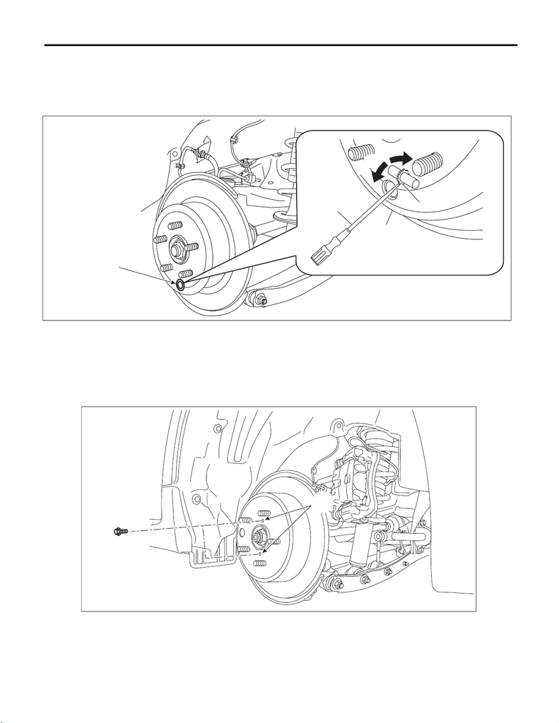

BR-40

Rear Disc Rotor

BRAKE

4) Remove the disc rotor.

NOTE:

If it is difficult to remove the disc rotor, perform the following two methods in order.

1. Remove the adjusting hole cover (A), insert the flat tip screwdriver, and rotate the adjuster assembly - rear

brake until the brake shoe moves far enough to remove the disc rotor.

2. When the disc rotor is difficult to be removed from the hub unit COMPL - rear axle, screw in 8 mm (0.31

in) bolt to the threaded part of the disc rotor (A), and remove the disc rotor.

(a) Adjuster ASSY - rear brake (c) Disc rotor (e) Shorten the adjuster ASSY - rear

brake

(b) Flat tip screwdriver (d) Extend the adjuster ASSY - rear

brake

PB-00247

(A)

(b)

(c)

(a)

(d)

(e)

BR-01280

(A)

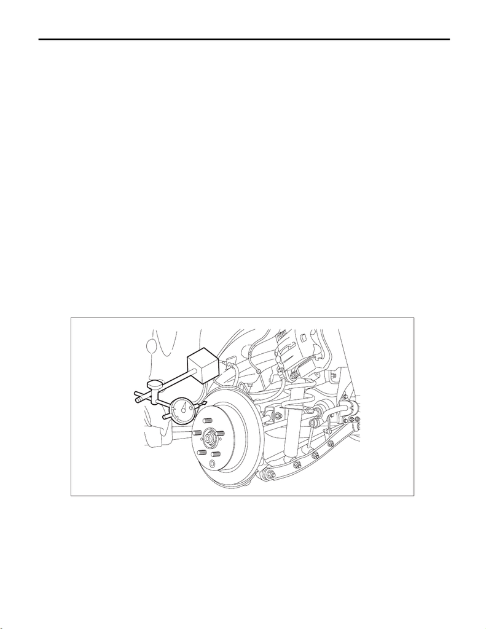

BR-41

Rear Disc Rotor

BRAKE

B: INSTALLATION

NOTE:

Before installation, remove mud and foreign matter from the disc brake assembly.

1) Check the rear disc rotor. <Ref. to BR-41, INSPECTION, Rear Disc Rotor.>

2) Install the disc rotor.

3) Adjust the parking brake. <Ref. to PB-16, ADJUSTMENT, Parking Brake Assembly (Rear Disc Brake).>

4) Install the disc brake assembly.

Tightening torque:

Mounting bolt (except for STI model): 66 N·m (6.7 kgf-m, 48.7 ft-lb)

Mounting bolt (STI model): 65 N·m (6.6 kgf-m, 47.9 ft-lb)

Brake hose bracket: 33 N·m (3.4 kgf-m, 24.3 ft-lb)

5) Install the rear wheels.

Tightening torque:

120 N·m (12.2 kgf-m, 88.5 ft-lb)

C: INSPECTION

1. DISC ROTOR RUNOUT CHECK

1) Check the hub unit COMPL - rear axle for free play and runout before the inspection of disc rotor runout

limit. <Ref. to DS-47, INSPECTION, Rear Hub Unit Bearing.>

2) Secure the disc rotor by tightening the five wheel nuts.

3) Set a dial gauge 10 mm (0.39 in) inward from the disc rotor outer circumference, and check the disc rotor

runout while rotating the disc rotor.

Disc rotor runout limit:

Except for STI model: 0.05 mm (0.0020 in)

STI model: 0.070 mm (0.0028 in)

4) If the disc rotor runout exceeds the limit, resurface the disc rotor.

5) After grinding, check the thickness of the disc rotor. <Ref. to BR-42, DISC ROTOR THICKNESS CHECK,

INSPECTION, Rear Disc Rotor.>

BR-01281

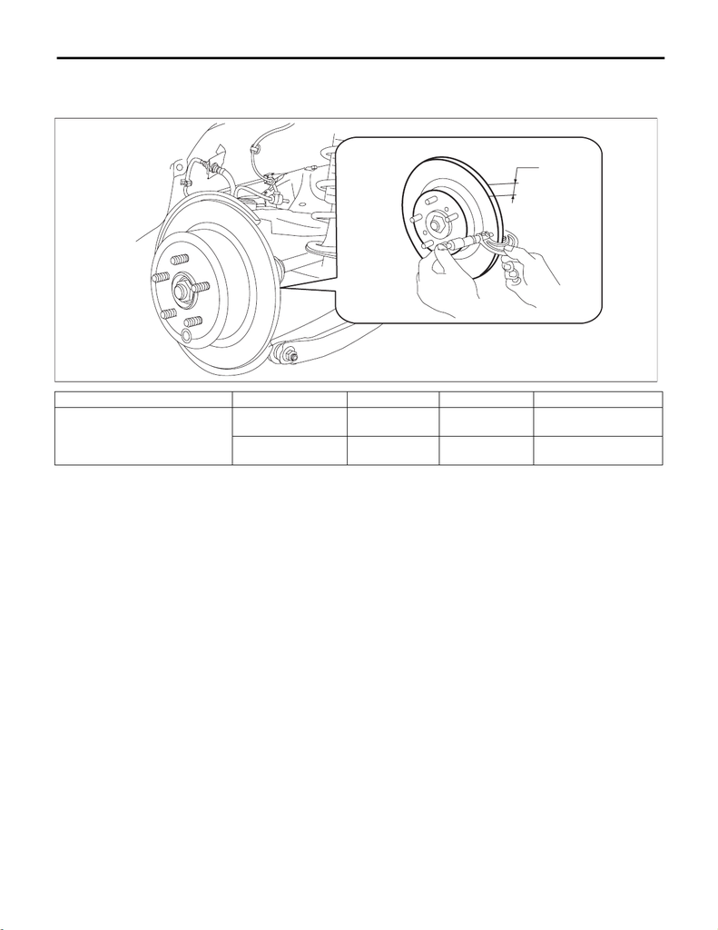

BR-42

Rear Disc Rotor

BRAKE

2. DISC ROTOR THICKNESS CHECK

1) Set a micrometer 10 mm (0.39 in) inward from the disc rotor outer perimeter, and then measure the disc

rotor thickness (A).

2) If the wear limit is exceeded in the inspection, replace the disc rotor.

Size Standard Wear limit Disc rotor outer diameter

Disc rotor thickness (A)

Except for STI model

10 mm

8.5 mm

(0.335 in)

286 mm

STI model

20 mm

(0.79 in)

18 mm

(0.71 in)

316 mm

(12.44 in)

(A)

BR-00915